# Replication Code: Age, Income, and the Discounting of Delayed Monetary Losses

## Hypothesis Testing: Bayesian Multilevel Models

This section replicates the main hypothesis tests from the paper, corresponding to Table 3. A series of four Bayesian multilevel beta regression models were fitted to test the effects of age, income, anxiety, and other covariates on AuC for participants aged 35 and older.

```r
# --- 5. HYPOTHESIS TESTING: BAYESIAN MULTILEVEL MODELS ---
# Models are cached to .rds files to avoid re-fitting, which can be time-consuming.

# --- Model 1: AuC ~ Age + Age^2 ---
# This model tests for a linear and quadratic effect of age on discounting.
# The significant quadratic term indicates the effect of age diminishes in older participants.
cat("--- Model 1: AuC ~ Age + Age^2 ---\n")
```

```
--- Model 1: AuC ~ Age + Age^2 ---
```

```r
DL_mod1b <- betaMLM_brm(Formula = bf(AuC ~ Age_std + I(Age_std^2) + (1 | ID)),
                        Data = DL_dat1, File = "rds/DL_mod1b")
print(brm_summary(DL_mod1b))
```

```
              Est.(SE)   pd
Intercept  .991 (.089) 1..0
Age        .446 (.116) 1..0
IAgeE2    -.581 (.272) .986
```

```r
# --- Model 2: AuC ~ Age + Age^2 + Income ---
# Adds income as a predictor. Higher income was associated with shallower discounting (larger AuC)].
cat("\n--- Model 2: AuC ~ Age + Age^2 + Income ---\n")
```

```
--- Model 2: AuC ~ Age + Age^2 + Income ---
```

```r
DL_mod2 <- betaMLM_brm(Formula = bf(AuC ~ Age_std + I(Age_std^2) + Income_std + (1|ID)),
                       Data = DL_dat2, File = "rds/DL_mod2")
print(brm_summary(DL_mod2))
```

```
              Est.(SE)   pd
Intercept  1..9 (.094) 1..0
Age        .462 (.119) 1..0
IAgeE2    -.622 (.285) .986
Income     .284 (.117) .992
```

```r
# --- Model 3: AuC ~ Age + Age^2 + Income + Anxiety ---
# Adds anxiety as a predictor. Anxiety was significant in this model.
cat("\n--- Model 3: AuC ~ Age + Age^2 + Income + Anxiety ---\n")
```

```
--- Model 3: AuC ~ Age + Age^2 + Income + Anxiety ---
```

```r
DL_mod3 <- betaMLM_brm(Formula = bf(AuC ~ Age_std + I(Age_std^2) + Income_std + Anxiety_std + (1|ID)),
                       Data = DL_dat3, File = "rds/DL_mod3")
print(brm_summary(DL_mod3))
```

```
              Est.(SE)   pd
Intercept  1..2 (.092) 1..0
Age        .377 (.127) .999
IAgeE2    -.588 (.278) .981
Income     .251 (.121) .980
Anxiety   -.290 (.131) .987
```

```r
# --- Model 4: Full Model with Covariates and Interactions ---
# The full model includes all covariates and their interactions with age.
cat("\n--- Model 4: Full Model with Covariates and Interactions ---\n")
```

```
--- Model 4: Full Model with Covariates and Interactions ---
```

```r
DL_mod4 <- betaMLM_brm(
  Formula = bf(AuC ~ (Age_std+Income_std + Anxiety_std + Amount_std + Education_std + Gender_c + Health_std)^2 + I(Age_std^2) + (1 + Amount_std|ID)),
  Data = DL_dat4, File = "rds/DL_mod4"
)
print(brm_summary(DL_mod4))
```

```
                      Est.(SE)   pd
Intercept          1..7 (.116) 1..0
Age                .416 (.148) .998
Income             .310 (.152) .981
Anxiety           -.259 (.164) .940
Amount            -.137 (.056) .992
Education         -.083 (.157) .698
Gender            -.058 (.139) .663
Health             .097 (.153) .738
IAgeE2            -.711 (.334) .981
Age:Income         .269 (.323) .806
Age:Anxiety       -.171 (.333) .701
Age:Amount         .337 (.116) .998
Age:Education      .110 (.313) .633
Age:Gender         .019 (.290) .527
Age:Health        -.090 (.336) .607
Income:Anxiety     .474 (.335) .925
Income:Amount      .055 (.124) .678
Income:Education   .119 (.308) .648
Income:Gender     -.207 (.306) .758
Income:Health     -.031 (.322) .538
Anxiety:Amount     .124 (.133) .827
Anxiety:Education  .010 (.289) .514
Anxiety:Gender    -.023 (.324) .527
Anxiety:Health    -.191 (.311) .736
Amount:Education   .102 (.120) .807
Amount:Gender     -.231 (.113) .977
Amount:Health     -.066 (.123) .700
Education:Gender   .492 (.306) .944
Education:Health   .191 (.365) .704
Gender:Health     -.119 (.309) .650
```

## Supplementary Analyses: Depression and Distress Models

The paper notes that while anxiety was a significant predictor of discounting, depression and overall psychological distress were not (when controlling for age and income). This section presents the models that confirm these findings.

```r
# --- 6. SUPPLEMENTARY ANALYSES: DEPRESSION & DISTRESS ---

# --- Model S1: Test effect of Depression ---
cat("--- Model S1: AuC ~ Age + Age^2 + Income + Depression ---\n")
```

```
--- Model S1: AuC ~ Age + Age^2 + Income + Depression ---
```

```r
DL_modS1 <- betaMLM_brm(Formula = bf(AuC ~ Age_std + I(Age_std^2) + Income_std + Depression_std + (1|ID)),
                        Data = DL_dat3, File = "rds/DL_modS1")
print(brm_summary(DL_modS1))
```

```
               Est.(SE)   pd
Intercept   1..2 (.092) 1..0
Age         .461 (.121) 1..0
IAgeE2     -.561 (.274) .982
Income      .290 (.123) .991
Depression -.058 (.122) .685
```

```r
# --- Model S2: Full model with Depression ---
cat("\n--- Model S2: Full Model with Depression and Interactions ---\n")
```

```
--- Model S2: Full Model with Depression and Interactions ---
```

```r
DL_modS2 <- betaMLM_brm(
  Formula = bf(AuC ~ (Age_std + Income_std + Depression_std + Amount_std + Education_std + Gender_c + Health_std)^2 + I(Age_std^2) + (1 + Amount_std|ID)),
  Data = DL_dat4, File = "rds/DL_modS2"
)
print(brm_summary(DL_modS2))
```

```
                         Est.(SE)   pd
Intercept             1..7 (.115) 1..0
Age                   .502 (.138) 1..0
Income                .295 (.158) .972
Depression            .005 (.171) .513
Amount               -.136 (.056) .993
Education            -.067 (.160) .662
Gender               -.077 (.137) .708
Health                .237 (.165) .927
IAgeE2               -.654 (.324) .983
Age:Income            .114 (.317) .639
Age:Depression        .116 (.330) .638
Age:Amount            .291 (.112) .995
Age:Education         .143 (.303) .680
Age:Gender            .013 (.284) .519
Age:Health            .057 (.332) .572
Income:Depression    -.243 (.355) .751
Income:Amount         .045 (.123) .644
Income:Education      .067 (.306) .584
Income:Gender        -.178 (.298) .726
Income:Health        -.309 (.343) .814
Depression:Amount    -.041 (.137) .616
Depression:Education -.038 (.311) .547
Depression:Gender    -.397 (.331) .881
Depression:Health    -.272 (.269) .840
Amount:Education      .095 (.122) .772
Amount:Gender        -.210 (.111) .969
Amount:Health        -.128 (.135) .837
Education:Gender      .434 (.303) .921
Education:Health      .095 (.371) .600
Gender:Health        -.307 (.329) .819
```

```r
# --- Model S3: Test effect of Distress ---
cat("\n--- Model S3: AuC ~ Age + Age^2 + Income + Distress ---\n")
```

```
--- Model S3: AuC ~ Age + Age^2 + Income + Distress ---
```

```r
DL_modS3 <- betaMLM_brm(Formula = bf(AuC ~ Age_std + I(Age_std^2) + Income_std + Distress_std + (1|ID)),
                        Data = DL_dat3, File = "rds/DL_modS3")
print(brm_summary(DL_modS3))
```

```
              Est.(SE)   pd
Intercept  1..5 (.091) 1..0
Age        .412 (.129) .999
IAgeE2    -.583 (.275) .985
Income     .262 (.124) .983
Distress  -.199 (.127) .943
```

```r
# --- Model S4: Full model with Distress ---
cat("\n--- Model S4: Full Model with Distress and Interactions ---\n")
```

```
--- Model S4: Full Model with Distress and Interactions ---
```

```r
DL_modS4 <- betaMLM_brm(
  Formula = bf(AuC ~ (Age_std + Income_std + Distress_std + Amount_std + Education_std + Gender_c + Health_std)^2 + I(Age_std^2) + (1+Amount_std|ID)),
  Data = DL_dat4, File = "rds/DL_modS4"
)
print(brm_summary(DL_modS4))
```

```
                       Est.(SE)   pd
Intercept           1..3 (.116) 1..0
Age                 .450 (.148) .999
Income              .325 (.160) .981
Distress           -.160 (.172) .824
Amount             -.137 (.056) .993
Education          -.078 (.161) .687
Gender             -.052 (.135) .648
Health              .136 (.165) .792
IAgeE2             -.683 (.331) .981
Age:Income          .195 (.327) .721
Age:Distress       -.046 (.346) .549
Age:Amount          .316 (.117) .997
Age:Education       .155 (.306) .687
Age:Gender         -.014 (.289) .518
Age:Health         -.080 (.338) .598
Income:Distress     .260 (.353) .773
Income:Amount       .050 (.125) .656
Income:Education    .086 (.310) .613
Income:Gender      -.191 (.295) .746
Income:Health      -.095 (.337) .610
Distress:Amount     .058 (.138) .658
Distress:Education -.009 (.302) .512
Distress:Gender    -.207 (.333) .740
Distress:Health    -.296 (.284) .857
Amount:Education    .103 (.123) .803
Amount:Gender      -.221 (.113) .973
Amount:Health      -.086 (.135) .737
Education:Gender    .455 (.309) .935
Education:Health    .134 (.373) .642
Gender:Health      -.178 (.324) .700
```

## Visualizing Key Interactions

This section replicates Figure 4 from the paper, visualizing the key findings from the full regression model (Model 4). The plots show the predicted AuC as a function of age, moderated by income level (left panel) and the magnitude of the loss (right panel). A significant Age x Amount interaction was found, where age differences were more pronounced for larger loss amounts.

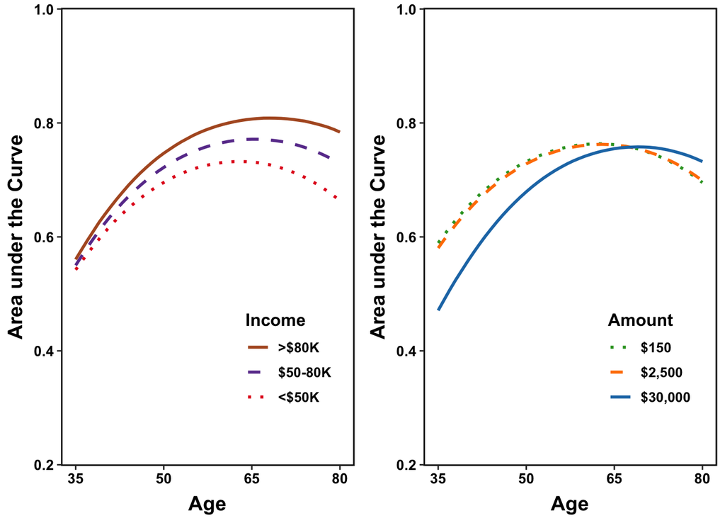

```r
# --- 7. VISUALIZING KEY INTERACTIONS (FIGURE 4 REPLICATION) ---

# --- Age x Income Interaction Plot ---
# This plot visualizes how the relationship between age and discounting (AuC)
# differs across low, medium, and high income groups.

# 1. Create a grid of predictor values to generate predictions for.
pred_grid_income <- expand(DL_dat4, Age = seq(35, 80, 1),
                           Income = c("<$50K","$50-80K",">$80K")) |>
  # 2. Scale Age and create mock variables for other predictors, holding them at their mean (0).
  mutate(Age_std = (Age - mean(DL_dat4$Age)) / (2*sd(DL_dat4$Age)),
         Income_std = case_when(Income == "<$50K" ~ (1.5 - mean(DL_dat4$Income)) / (2*sd(DL_dat4$Income)),
                                Income == "$50-80K" ~ (3 - mean(DL_dat4$Income)) / (2*sd(DL_dat4$Income)),
                                Income == ">$80K" ~ (4.5 - mean(DL_dat4$Income)) / (2*sd(DL_dat4$Income))),
         Amount_std = 0, Education_std = 0, Gender_c = 0,
         Anxiety_std = 0, Health_std = 0,
         Income = factor(Income, levels = c(">$80K","$50-80K","<$50K")))

# 3. Generate posterior predictions from the model using the grid.
p_income <- add_epred_draws(DL_mod4, newdata = pred_grid_income, re_formula = NA) |>
  # 4. Summarize the posterior draws to get the median predicted AuC for each point.
  group_by(Age, Income) |>
  summarize(.epred = median(.epred), .groups = 'drop') |>
  # 5. Build the ggplot object.
  ggplot(aes(x = Age, y = .epred, fill = Income, color = Income)) +
  geom_line(aes(linetype = Income), size = 1) +
  labs(x = "Age", y = "Area under the Curve", color = "Income", fill = "Income", linetype = "Income") +
  scale_y_continuous(limits = c(.198, 1.002), breaks = seq(.2,1,.2), expand = c(0,0)) +
  scale_x_continuous(limits = c(33.5,81.5), breaks = seq(35,80,15), expand = c(0,1)) +
  scale_color_manual(values = c(">$80K"="#b15928","$50-80K"="#6a3d9a","<$50K"="#e31a1c")) +
  scale_fill_manual(values = c(">$80K"="#b15928","$50-80K"="#6a3d9a","<$50K"="#e31a1c")) +
  scale_linetype_manual(values = c(">$80K"="solid","$50-80K"="dashed","<$50K"="dotted")) +
  theme_bw() + mattheme +
  theme(legend.position = c(.77, .23))

# --- Age x Amount Interaction Plot ---
# This plot visualizes how the relationship between age and discounting
# differs across the small, medium, and large loss amounts.

# 1. Create prediction grid.
pred_grid_amount <- expand(DL_dat4, Age = seq(35, 80, 1),
                           Amount = c(150, 2500, 30000)) |>
  # 2. Scale Age and Amount, hold other predictors at their mean.
  mutate(
    Age_std = (Age - mean(DL_dat4$Age)) / (2*sd(DL_dat4$Age)),
    Amount_std = (Amount - mean(DL_dat4$Amount)) / (2*sd(DL_dat4$Amount)),
    Income_std = 0, Education_std = 0, Gender_c = 0,
    Anxiety_std = 0, Health_std = 0,
    Amount_Factor = factor(Amount, levels = c(150, 2500, 30000), labels = c("$150", "$2,500", "$30,000"))
  )

# 3. Generate posterior predictions.
p_amount <- add_epred_draws(DL_mod4, newdata = pred_grid_amount, re_formula = NA) |>
  # 4. Summarize posteriors.
  group_by(Age, Amount_Factor) |>
  summarize(.epred = median(.epred), .groups = 'drop') |>
  # 5. Build ggplot object.
  ggplot(aes(x = Age, y = .epred, group = Amount_Factor, color = Amount_Factor)) +
  geom_line(aes(linetype = Amount_Factor), size = 1) +
  labs(x = "Age", y = "Area under the Curve", color = "Amount", linetype = "Amount") +
  scale_y_continuous(limits = c(.198, 1.002), breaks = seq(.2,1,.2), expand = c(0,0)) +
  scale_x_continuous(limits = c(33.5,81.5), breaks = seq(35,80,15), expand = c(0,1)) +
  scale_linetype_manual(values = c("$30,000"="solid","$2,500"="dashed","$150"="dotted")) +
  scale_color_manual(values = c("$30,000"="#1f78b4","$2,500"= "#ff7f00","$150"="#33a02c")) +
  theme_bw() + mattheme +
  theme(legend.position = c(.77, .23))

# Arrange and display plots side-by-side using ggarrange
ggarrange(p_income, p_amount, ncol = 2, common.legend = FALSE)
```